# Kaminda - Practical 4

# I anticipate that there will be similar correlation; that in the time right before and after opening, the EEG will be most intense, and in the time when eyes are closed, the EEG will be the least intense.

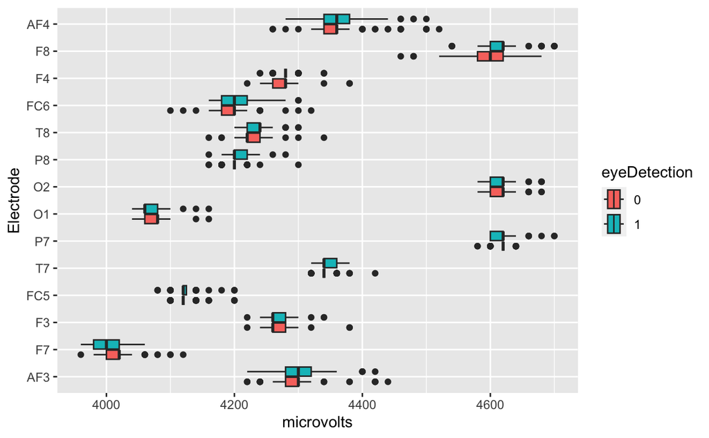

```r
melt_train <- reshape2::melt(eeg_train, id.vars=c("eyeDetection", "ds"), variable.name = "Electrode", value.name = "microvolts")

# filter huge outliers in voltage
filt_melt_train <- dplyr::filter(melt_train, microvolts %in% (3750:5000)) %>% dplyr::mutate(eyeDetection=as.factor(eyeDetection))

ggplot2::ggplot(filt_melt_train, ggplot2::aes(y=Electrode, x=microvolts, fill=eyeDetection)) + ggplot2::geom_boxplot()
```

```r
filt_melt_train %>% dplyr::group_by(eyeDetection, Electrode) %>%
    dplyr::summarise(mean = mean(microvolts), median=median(microvolts), sd=sd(microvolts)) %>%
    dplyr::arrange(Electrode)
```

| eyeDetection | Electrode | mean | median | sd |
| --- | --- | --- | --- | --- |
| 0 | AF3 | 4294.453 | 4300 | 35.37446 |
| 1 | AF3 | 4304.528 | 4300 | 34.39635 |
| 0 | F7 | 4014.775 | 4020 | 28.37562 |
| 1 | F7 | 4006.733 | 4000 | 24.86399 |
| 0 | F3 | 4267.736 | 4260 | 20.94360 |
| 1 | F3 | 4268.750 | 4260 | 17.35299 |
| 0 | FC5 | 4123.850 | 4120 | 17.29376 |
| 1 | FC5 | 4124.107 | 4120 | 19.19805 |
| 0 | T7 | 4341.379 | 4340 | 13.88753 |
| 1 | T7 | 4342.045 | 4340 | 15.47405 |

[output cut: 18 more lines]

**4**

# Based on these analyses, electrodes F8, O2, and P7 are consistently more intense than the others.

### Time-Related Trends

```r
apply(eeg_train, 2, tseries::adf.test)
```

```
$AF3

    Augmented Dickey-Fuller Test

data:  newX[, i]
Dickey-Fuller = -20.669, Lag order = 20, p-value = 0.01
alternative hypothesis: stationary


$F7

    Augmented Dickey-Fuller Test

data:  newX[, i]
Dickey-Fuller = -12.079, Lag order = 20, p-value = 0.01
alternative hypothesis: stationary


$F3

    Augmented Dickey-Fuller Test

data:  newX[, i]
Dickey-Fuller = -11.587, Lag order = 20, p-value = 0.01
alternative hypothesis: stationary


$FC5

    Augmented Dickey-Fuller Test

data:  newX[, i]
Dickey-Fuller = -11.122, Lag order = 20, p-value = 0.01
alternative hypothesis: stationary


$T7

    Augmented Dickey-Fuller Test

```

[output cut: 87 more lines]

```

    Augmented Dickey-Fuller Test

data:  newX[, i]
Dickey-Fuller = -4.8699, Lag order = 20, p-value = 0.01
alternative hypothesis: stationary


$ds

    Augmented Dickey-Fuller Test

data:  newX[, i]
Dickey-Fuller = -2.4104, Lag order = 20, p-value = 0.4045
alternative hypothesis: stationary
```

**5**

# Stationarity refers to the statistical properties of a time-series not changing over time. A stationary time-series will have a constant mean and variance, and will generally exhibit a linear function.

**6**

# We are interested in stationarity because we are modelling time-series data. Stationarity allows us to use a simplified analysis and make assumptions based on the stability of statistical properties.

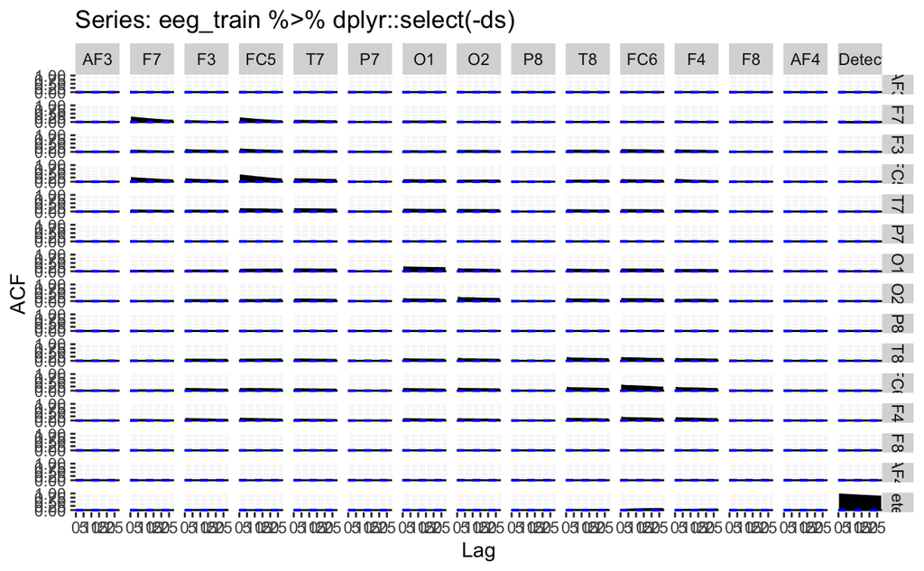

```r
forecast::ggAcf(eeg_train %>% dplyr::select(-ds))
```

**7**